# Fish-Ecol Org

Faúndez-Baez, P., Hartline, N., Mayorga-Henao, J., Villaseñor-Derbez, J.C.

## Link to our final paper

[Here!](http://fish-ecol.github.io/Project_Final_Paper.html)

## Link to our presentation

[Here!](https://jcvd.shinyapps.io/Presentation/#1)

## Types of data

We have the following data:

- IUCN: Data on endangerment of fish species (Chondricthyes). The data will include trend, global status, country, habitat (freshwater or marine), and other species details. Some of these data sets will need to be joined.

## Data and metadata standards

Data comes from the International Union for Conservation of Nature: IUCN Red List of Threatened Species http://www.iucnredlist.org The IUCN Red List of Threatened Species is widely recognized as the most comprehensive, objective global approach for evaluating the conservation status of plant and animal species. From its small beginning, the IUCN Red List has grown in size and complexity and now plays an increasingly prominent role in guiding conservation activities of governments, NGOs and scientific institutions. The introduction in 1994 of a scientifically rigorous approach to determine risks of extinction that is applicable to all species, has become a world standard. In order to produce the IUCN Red List of Threatened Species, the IUCN Species Programme working with the IUCN Survival Commission (SSC) and with members of IUCN draws on and mobilizes a network of scientists and partner organizations working in almost every country in the world, who collectively hold what is likely the most complete scientific knowledge base on the biology and conservation status of species.

## Policies for access and sharing

All data, program code and results are freely available via the service GitHub https://github.com/fish-ecol

Data should be cited as:

IUCN 2015. The IUCN Red List of Threatened Species. Version 2015-4. http://www.iucnredlist.org. Downloaded on 05 February 2016.

## Plans for archiving and preservation of access

We will submit our story and data to a [dataMares](http://datamares.ucsd.edu/eng/).

## Data question(s)

You can also take a look at our [Interactive Visualizations!](http://fish-ecol.github.io/wk06_widgets_group.html)

### IUCN Data for Elasmobranchs

Some descriptive stuff for us to know what we have.

**Table 1-** Taxonomic summary of the IUCN data.

| Classes | Orders | Families | Species |
| --- | --- | --- | --- |
| 1 | 9 | 57 | 1043 |

How many species are listed as eac category by Order?

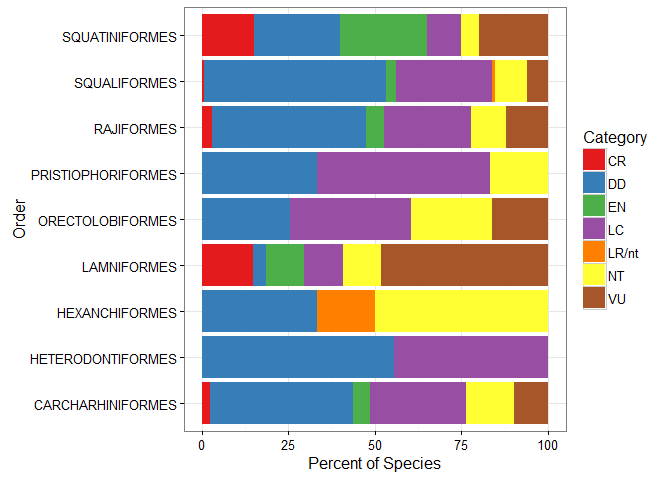

Categories for ech Order

How many species are listed within each category?

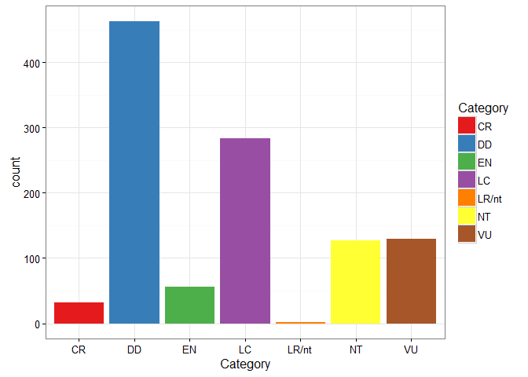

How has number of species changed for each category throughout the years?

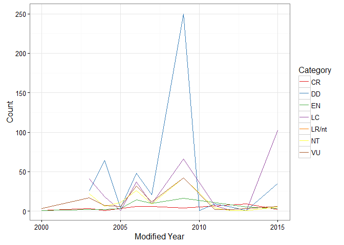

```
## [1] "Fish Class compared to habitat systems"
```

```
##
##                      Freshwater Freshwater; Marine Marine
##   Actinopterygii           6555                680   5714
##   Cephalaspidomorphi         28                  4      0
##   Chondrichthyes             25                 19   1075
##   Myxini                      0                  0     76
##   Sarcopterygii               5                  0      2
```

```
## [1] "There is a significant association between fish class and habitat system"
```

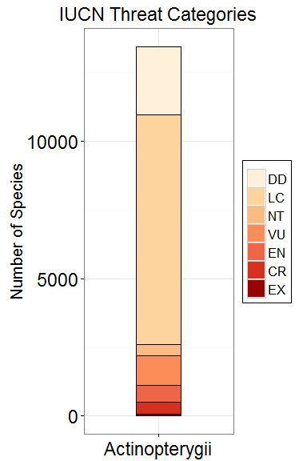

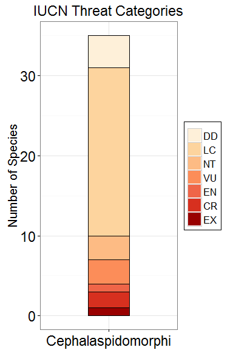

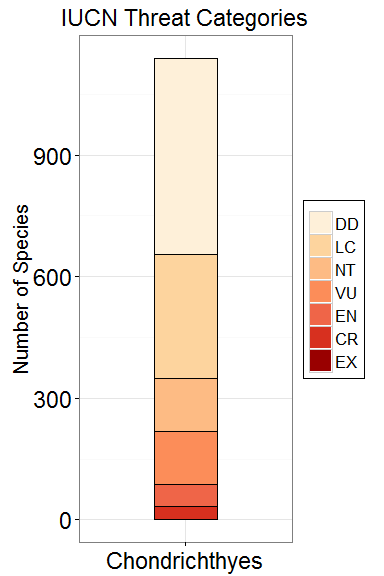

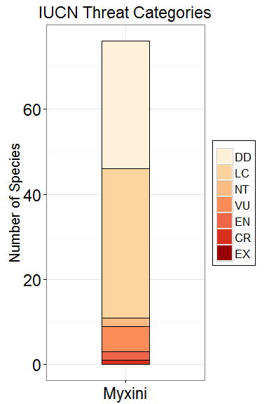

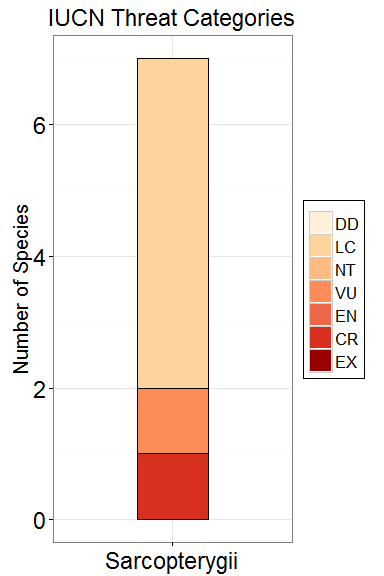